# Project 1

Tanja Venborg

4 August 2016

# Loading the data

First the activity data will be loaded

```r
data <- read.csv("/Users/Thansen/Desktop/R/ReproducibleResearch/activity.csv")
data <- na.omit(data)
```

# Processing data

Here I find the sum of the steps taken each day. I start by looking at the data. Then I create a new datatable, where the steps are summed up by date, then I add the columnnames. Finally I print the new steps table, where its now clear how many steps where taken each of the dates where ther is a step.

```r
head(data)
```

```
##     steps       date interval
## 289     0 2012-10-02        0
## 290     0 2012-10-02        5
## 291     0 2012-10-02       10
## 292     0 2012-10-02       15
## 293     0 2012-10-02       20
## 294     0 2012-10-02       25
```

```r
library(data.table)
stepstabel <-  as.data.table(data)[, by = . (date), sum(steps)]
colnames(stepstabel) <- c("Date","steps")
stepstabel$Date <- format(as.Date(stepstabel$Date), "%Y/%m/%d")
print(stepstabel)
```

```
##           Date steps
##  1: 2012/10/02   126
##  2: 2012/10/03 11352
##  3: 2012/10/04 12116
##  4: 2012/10/05 13294
##  5: 2012/10/06 15420
##  6: 2012/10/07 11015
##  7: 2012/10/09 12811
##  8: 2012/10/10  9900
##  9: 2012/10/11 10304
## 10: 2012/10/12 17382
## 11: 2012/10/13 12426
## 12: 2012/10/14 15098
## 13: 2012/10/15 10139
## 14: 2012/10/16 15084
```

[output cut: 40 more lines]

# Creating a histogram

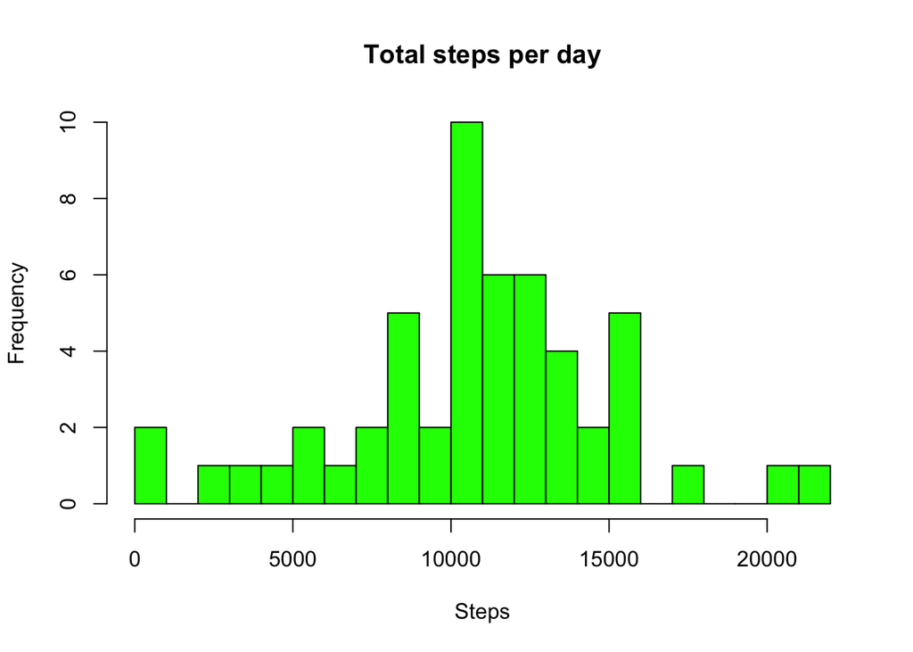

```r
steps1 <- hist(stepstabel$steps, breaks =20, main = "Total steps per day", xlab ="Steps", ylab =  "Frequency", col ="green")
```

# Plotting the daily activity pattern

To create the plot, i first stort the data in a sum of step by the intervals. To get the line plot, I type = “l”. If this isn’t specified, the plot will be a scatterplot.

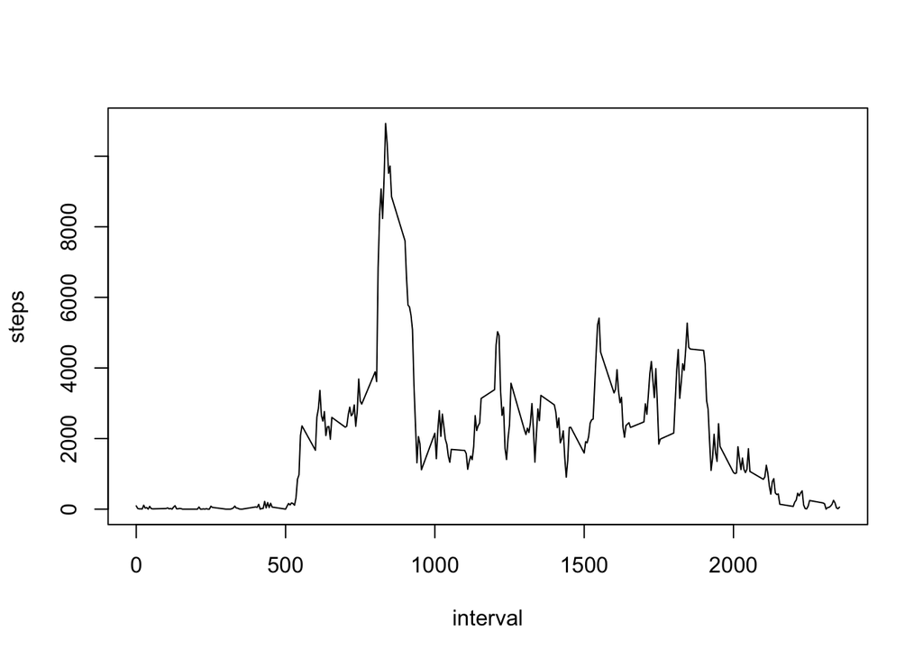

```r
interval <- as.data.table(data)[,sum(steps), by = .(interval)]
colnames(interval) <- c("interval", "steps")
plot(interval, type = "l")
```

Finding the interval with the maximum numbers of steps is pretty straight forward.

```r
maxstep <- sapply (interval, max)
interval[steps %in% maxstep,]
```

```
##    interval steps
## 1:      835 10927
```

This means that interval 835 has the largest amount of steps.

# Imputing missing values

Since I removed the NA’s from the first dataset, I reload it and in a new data name. Calculating the total amount of missing values from the original dataset

```r
orgdata <- read.csv("/Users/Thansen/Desktop/R/ReproducibleResearch/activity.csv")
sum(is.na(orgdata))
```

```
## [1] 2304
```

```r
nrow(orgdata)
```

```
## [1] 17568
```

```r
sum(is.na(orgdata))/nrow(orgdata)
```

```
## [1] 0.1311475
```

There was 2304 missing values. That seems like quite a lot, actually it is 13%.

To fill in the missing values, I take the mean of the filled-in days.

```r
orgdata$steps[is.na(orgdata$steps)] <-  mean(data$steps, na.rm = FALSE)
head(orgdata)
```

```
##     steps       date interval
## 1 37.3826 2012-10-01        0
## 2 37.3826 2012-10-01        5
## 3 37.3826 2012-10-01       10
## 4 37.3826 2012-10-01       15
## 5 37.3826 2012-10-01       20
## 6 37.3826 2012-10-01       25
```

```r
sum(is.na(orgdata))
```

```
## [1] 0
```

There is no longer any missing values in the data.

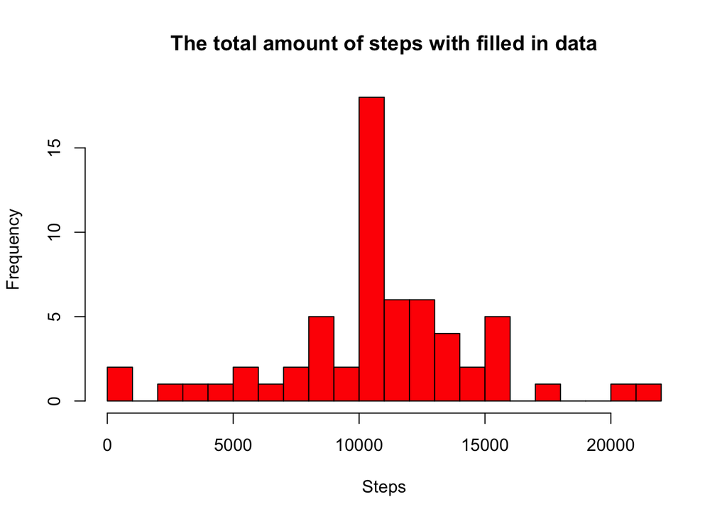

```r
filled_in_data <-  as.data.table(orgdata)[, by = . (date), sum(steps)]
colnames(filled_in_data) <- c("interval", "steps")
steps2 <- hist(filled_in_data$steps, breaks = 20, xlab = "Steps", main = "The total amount of steps with filled in data", col ="red")
```

Combining the two histograms to see the difference

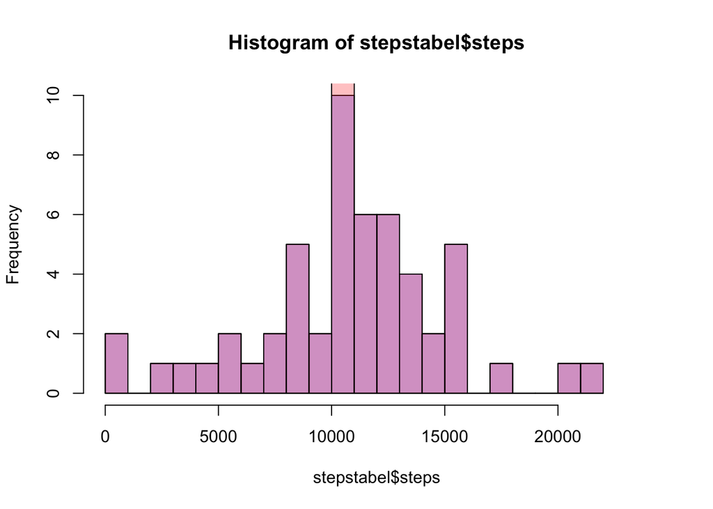

```r
set.seed(42)
plot(steps1, col = rgb(0,0,1, 1/4), xlim = c(0,24000))
plot(steps2, col = rgb(1,0,0,1/4), xlim = c(0,24000), add=T)
```

# Weekdays vs weekends

First I’m adding and extra row where the weekend, weekday distinguishion is made.

```r
orgdata$realdate <-  as.Date(orgdata$date, format = "%Y-%m-%d")
orgdata$weekday <- weekdays(orgdata$realdate)

orgdata$daytype <- ifelse(orgdata$weekday == "Saturday" | orgdata$weekday == "Sunday", "weekend", "weekday")
head(orgdata, n = 10)
```

```
##      steps       date interval   realdate weekday daytype
## 1  37.3826 2012-10-01        0 2012-10-01  Monday weekday
## 2  37.3826 2012-10-01        5 2012-10-01  Monday weekday
## 3  37.3826 2012-10-01       10 2012-10-01  Monday weekday
## 4  37.3826 2012-10-01       15 2012-10-01  Monday weekday
## 5  37.3826 2012-10-01       20 2012-10-01  Monday weekday
## 6  37.3826 2012-10-01       25 2012-10-01  Monday weekday
## 7  37.3826 2012-10-01       30 2012-10-01  Monday weekday
## 8  37.3826 2012-10-01       35 2012-10-01  Monday weekday
## 9  37.3826 2012-10-01       40 2012-10-01  Monday weekday
## 10 37.3826 2012-10-01       45 2012-10-01  Monday weekday
```

Plotting the weekdays vs. weekends

```r
sumdata_interval <- aggregate(steps~interval+daytype,data = orgdata, FUN = mean, na.action = na.omit)
head(sumdata_interval)
```

```
##   interval daytype    steps
## 1        0 weekday 7.006569
## 2        5 weekday 5.384347
## 3       10 weekday 5.139902
## 4       15 weekday 5.162124
## 5       20 weekday 5.073235
## 6       25 weekday 6.295458
```

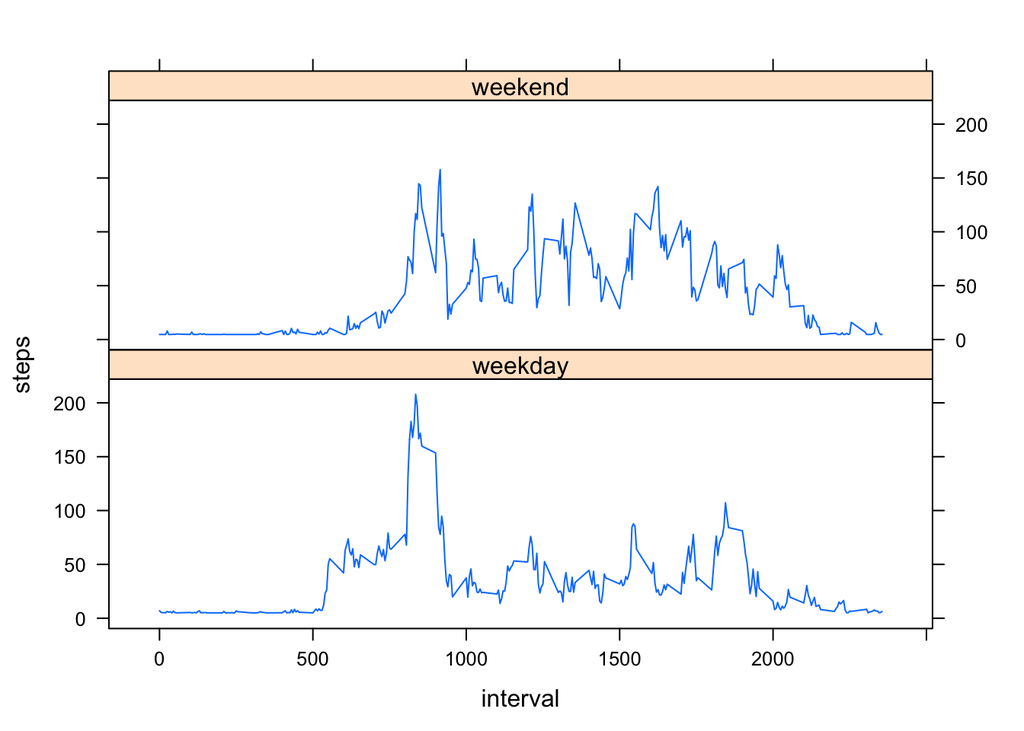

```r
library(lattice)
xyplot(steps ~interval | daytype, data= sumdata_interval, layout =c(1,2), type = "l")
```